# pilot1

Samah

2023-03-14

# Preliminaries and data reading

```r
# additional libraries
library("knitr")
library("janitor")
library("broom.mixed")
library("lme4")
library("emmeans")
library("tidyverse")
library("kableExtra")
library("modelr")
library("broom")
library("nlme")
library("meta")
library("metafor")
library(jtools) # Load jtools
theme_set(theme_bw())
```

```r
# reading the data file
pilot1_data = read_csv("252.csv")
df_shape= filter(pilot1_data, !is.na(d))
# pilot1_data = pilot1_data %>%
#   select(ID, Title, d, d_var, Author)

df_shape_summary = df_shape %>%
  group_by(ID, Title, Author) %>%
  summarize(mean = mean(d),
            mean_se = mean(d_var))
```

# Initial exploration

First, Visualizing the data to have an initial idea of how it looks.

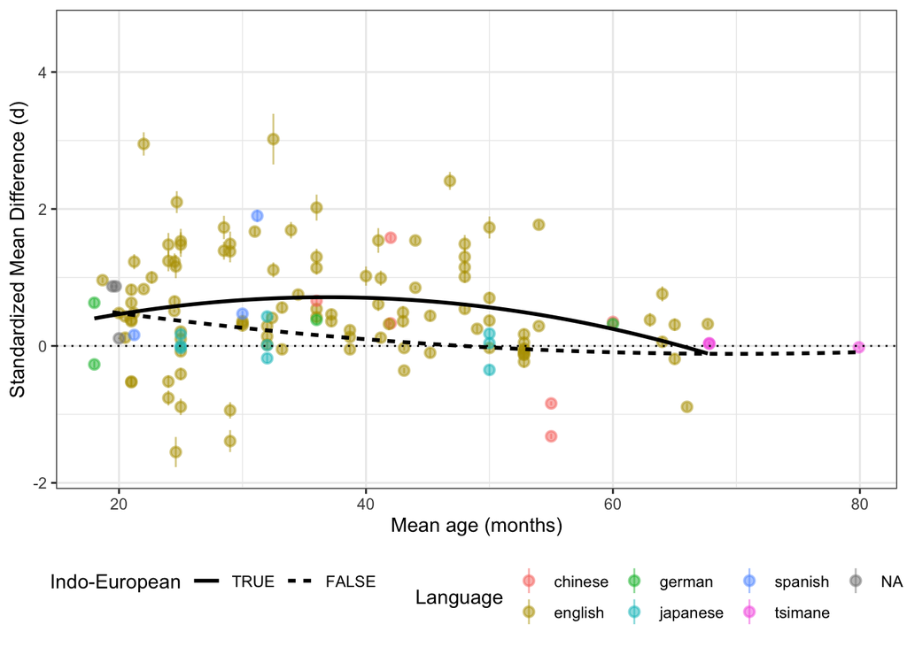

```r
df_shape$indoeuropean <- fct_relevel(as.factor(df_shape$language %in%
                                                 c("english","spanish", "german")),
                                     "TRUE")

# creating a plot that shows the effects sizes colored per language group as well as the polynomial regression curve that fits it.

ggplot(df_shape,
       aes(x = mean_age_months, y = d, color = language))+
  geom_pointrange(aes(ymin = d - d_var, ymax = d + d_var),
                  alpha = .5) +
  geom_smooth(aes(group = indoeuropean,
                  lty  = indoeuropean),
              col = "black",
              method = "lm", se = FALSE,
              formula = y ~ poly(x,2)) +
  geom_hline(yintercept = 0, lty = 3) +
  ylab("Standardized Mean Difference (d)") +
  xlab("Mean age (months)") +
  scale_color_discrete(name = "Language") +
  scale_linetype_discrete(name = "Indo-European") +
  theme(legend.position = "bottom")
```

```r
# ggsave("first graph.png", width = 7, height = 4)
```

## `metagen` approach

using the meta-analytic function meta-gen which calculates the weights for each effects and confidence interval, pooled effect size, the heterogeneity.

```r
m.gen <- metagen( TE= d,
                  seTE = d_var,
                  studlab = ID,
                  data = df_shape,
                  sm = "SMD",
                  fixed = FALSE,
                  random = TRUE,
                  method.tau = "REML",
                  hakn = TRUE,
                  title = "pilot shape bias meta-analysis"

)

# summary(m.gen)['TE']
# m.gen["TE.fixed"]
# m.gen["TE.random"]
# m.gen["w.random"]
```

forest plot using the m-gen function object

```r
forextobj <- forest.meta(m.gen,
                         sortvar = TE,
                         prediction = TRUE,
                         print.tau2 = FALSE,
                         leftlabs = c("Author", "g", "SE"))
```

[figure not shown]

forest plot from the rma model

## `metafor` approach

using rma.mv instead of m.gen

```r
mod <- rma.mv(yi = d,
              V = d_var,
              random = ~ 1 | ID,
              slab = short_cite,
              data = df_shape)
summary(mod)
```

```
##
## Multivariate Meta-Analysis Model (k = 140; method: REML)
##
##    logLik   Deviance        AIC        BIC       AICc
## -345.7749   691.5499   695.5499   701.4188   695.6381
##
## Variance Components:
##
##             estim    sqrt  nlvls  fixed  factor
## sigma^2    0.1518  0.3897     25     no      ID
##
## Test for Heterogeneity:
## Q(df = 139) = 959.8543, p-val < .0001
##
## Model Results:
##
## estimate      se    zval    pval   ci.lb   ci.ub
##   0.4669  0.0828  5.6377  <.0001  0.3046  0.6293  ***
##
## ---
## Signif. codes:  0 '***' 0.001 '**' 0.01 '*' 0.05 '.' 0.1 ' ' 1
```

Nested model.

```r
mod_nested <- rma.mv(yi = d,
                     V = d_var,
                     random = ~ 1 | ID/exp_num,
                     slab = short_cite,
                     data = filter(df_shape, !is.na(exp_num)))

summary(mod_nested)
```

```
##
## Multivariate Meta-Analysis Model (k = 133; method: REML)
##
##    logLik   Deviance        AIC        BIC       AICc
## -328.8672   657.7344   663.7344   672.3828   663.9219
##
## Variance Components:
##
##             estim    sqrt  nlvls  fixed      factor
## sigma^2.1  0.1446  0.3803     25     no          ID
## sigma^2.2  0.0093  0.0964     34     no  ID/exp_num
##
## Test for Heterogeneity:
## Q(df = 132) = 895.1881, p-val < .0001
##
## Model Results:
##
## estimate      se    zval    pval   ci.lb   ci.ub
##   0.4670  0.0838  5.5735  <.0001  0.3028  0.6312  ***
##
## ---
## Signif. codes:  0 '***' 0.001 '**' 0.01 '*' 0.05 '.' 0.1 ' ' 1
```

Forest plot from `metafor`.

[figure not shown]

```r
forest(mod)
```

Try this using ggplot

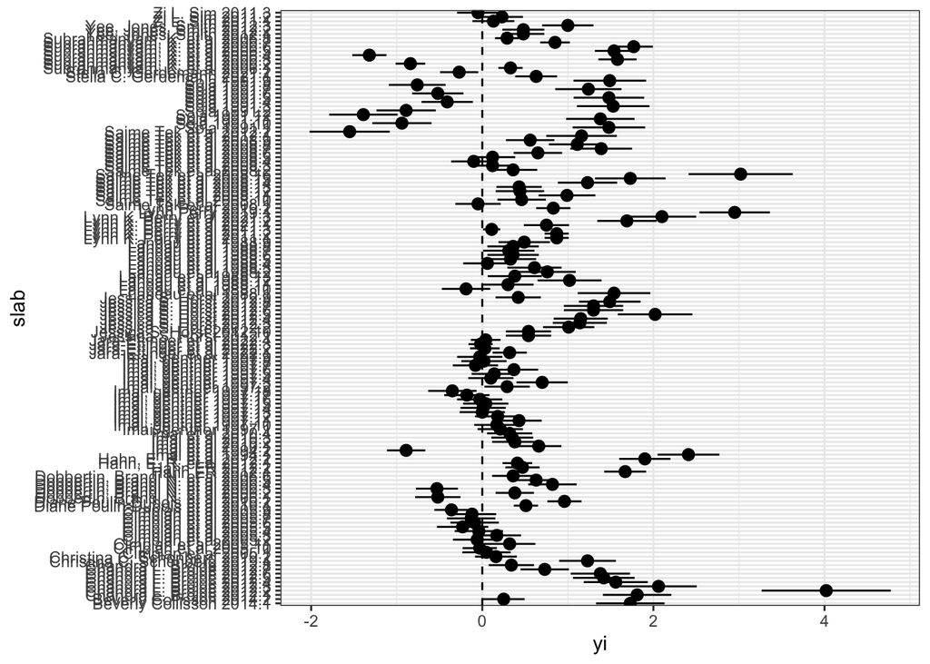

```r
forest_data <-tibble(yi = mod$yi,
                     se = sqrt(mod$vi),
                     slab = mod$slab)

ggplot(forest_data,
       aes(x = slab, y = yi)) +
  geom_pointrange(aes(ymin = yi - se, ymax = yi + se)) +
  geom_hline(yintercept = 0, lty = 2) +
  coord_flip()
```

```r
#
# theme_set(theme_bw(base_size=10))
# ata.frame(ES=ROM.ma$b,SE=ROM.ma$se,Type="Summary",Study="Summary"))
# forrest_data$Study2<-factor(forrest_data$Study, levels=rev(levels(forrest_data$Study)) )
# levels(forrest_data$Study2)
# plot1<-ggplot(data=forrest_data,aes(x=Study2,y=ES,ymax=ES+(1.96*SE),ymin=ES-(1.96*SE),size=factor(Type),colour=factor(Type)))+geom_pointrange()
# plot2<-plot1+coord_flip()+geom_hline(aes(x=0), lty=2,size=1)+scale_size_manual(values=c(0.5,1))
# plot3<-plot2+xlab("Study")+ylab("log response ratio")+scale_colour_manual(values=c("grey","black"))
# plot3+theme(legend.position="none")
```

## Revised forest plot

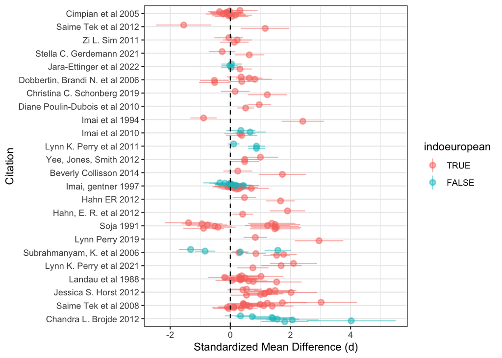

```r
df_shape$mean_age_months_centered36 <- df_shape$mean_age_months - 36
df_shape$log_mean_age_months <- log(df_shape$mean_age_months)

ggplot(df_shape, aes(x = short_cite, y = d,
                     ymin=d-sqrt(d_var)*1.96,
                     ymax=d+sqrt(d_var)*1.96)) +
  geom_pointrange(aes(color=indoeuropean), alpha = .5, position=position_dodge2(width=.5)) +
  coord_flip() +
  geom_hline(yintercept = 0, lty = 2) +
  aes(x=reorder(short_cite,-d, sum)) +
  ylab("Standardized Mean Difference (d)") +
  xlab("Citation")
```

```r
#png("secondgraph.png")
```

```r
col.contour = c("gray75", "gray85", "gray95")

funnel(m.gen,
       comb.random = TRUE,
       xlim = c(-2, 4),
       contour = c(0.9, 0.95, 0.99),
       col.contour = col.contour)

regtest(x = d, vi = d_var,
        data = df_shape)
```

```
##
## Regression Test for Funnel Plot Asymmetry
##
## Model:     mixed-effects meta-regression model
## Predictor: standard error
##
## Test for Funnel Plot Asymmetry: z = 6.6402, p < .0001
## Limit Estimate (as sei -> 0):   b = -0.8597 (CI: -1.2814, -0.4381)
```

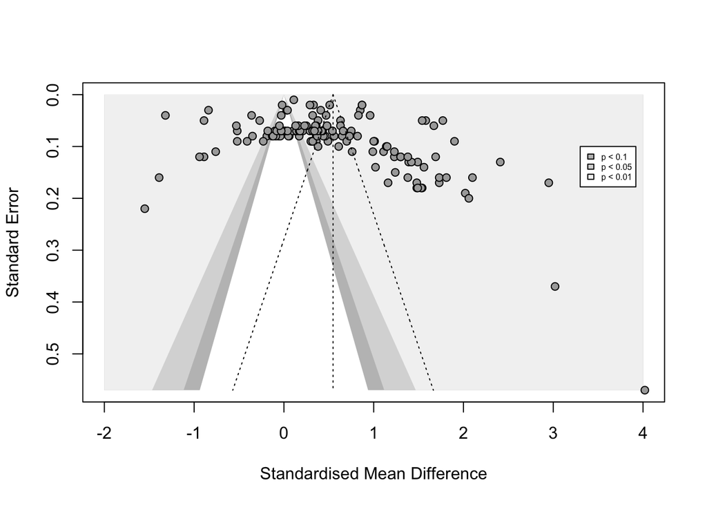

```r
# Add a legend
legend(x = 3.3, y = 0.1, cex = 0.5,
       legend = c("p < 0.1", "p < 0.05", "p < 0.01"),
       fill = col.contour)
```

```r
#png("funnel.png")
```

## Publication bias

funnel plots using ggplot to account for moderators:

```r
x = summary(m.gen)['TE']
y = summary(m.gen)['seTE']
m.gen["TE.fixed"]
```

```
## $TE.fixed
## [1] 0.317156
```

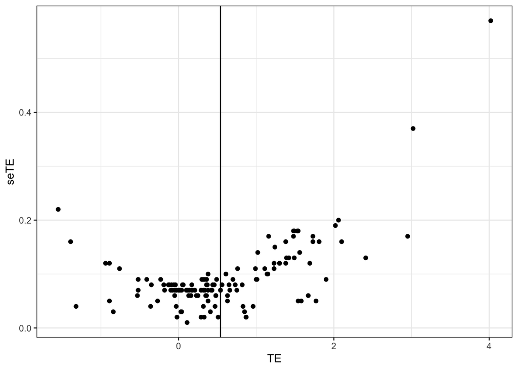

```r
ter = m.gen["TE.random"]


data.gen = data.frame(x,y,ter)

ggplot(data = data.gen, mapping = aes(x=TE, y = seTE, color= )) +
  geom_point() +
  geom_vline(xintercept = 0.5401759)
```

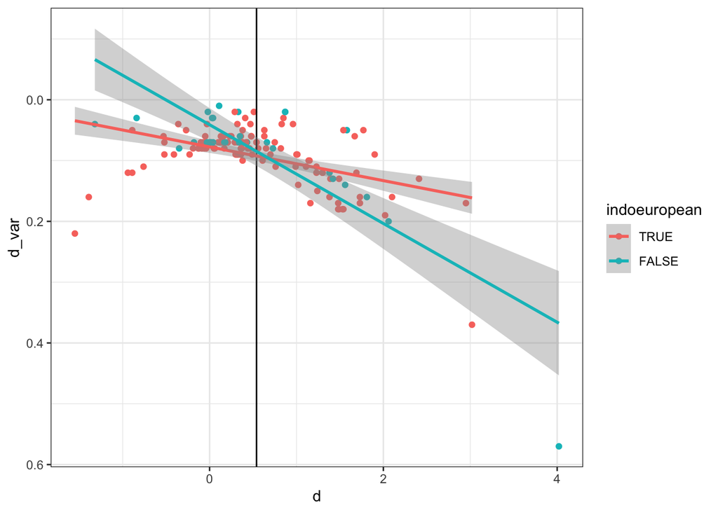

```r
ggplot(data = df_shape, mapping = aes(x=d, y = d_var, color= indoeuropean)) +
  geom_point() +
  geom_vline(xintercept = 0.5401759) +
  scale_y_reverse() +
  geom_smooth(method = "lm")
```

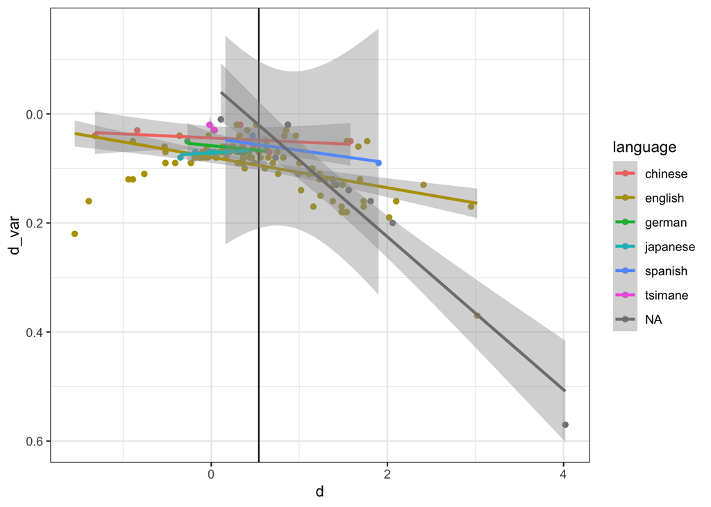

```r
ggplot(data = df_shape, mapping = aes(x=d, y = d_var, color= language)) +
  geom_point() +
  geom_vline(xintercept = 0.5401759) +
  scale_y_reverse() +
  geom_smooth(method = "lm")
```

# Confirmatory analysis

For primary analyses, i will exclude effect sizes from clinical populations and multilingual populations.

I will investigate the hypotheses via multi-level meta-regressions using the metafor package.

In all models, I will include random effects that control for non-independence between effect sizes based on grouping by paper and grouping by experiment.

I will first fit: Shape bias ~ 1 Shape bias ~ age shape bias ~ log(age) shape bias ~ poly(age,2)

### intercept:

```r
# using the meta and metafor packages to analyze meta-analysis effect sizes
mod_intercept <- rma.mv(d ~ 1,
                        V = d_var,
                        random = ~1 | as.factor(Title) /
                          as.factor(exp_num),
                        slab = Title,
                        data = filter(df_shape, !is.na(exp_num)))

summary(mod_intercept)
```

```
##
## Multivariate Meta-Analysis Model (k = 133; method: REML)
##
##    logLik   Deviance        AIC        BIC       AICc
## -328.4943   656.9886   662.9886   671.6370   663.1761
##
## Variance Components:
##
##             estim    sqrt  nlvls  fixed                               factor
## sigma^2.1  0.1519  0.3897     26     no                     as.factor(Title)
## sigma^2.2  0.0027  0.0524     34     no  as.factor(Title)/as.factor(exp_num)
##
## Test for Heterogeneity:
## Q(df = 132) = 895.1881, p-val < .0001
##
## Model Results:
##
## estimate      se    zval    pval   ci.lb   ci.ub
##   0.4776  0.0828  5.7691  <.0001  0.3154  0.6399  ***
##
## ---
## Signif. codes:  0 '***' 0.001 '**' 0.01 '*' 0.05 '.' 0.1 ' ' 1
```

### age

```r
mod_age <- rma.mv(d ~ mean_age_months_centered36,
                  V = d_var,
                  random = ~1 | as.factor(Title) /
                    as.factor(exp_num),
                  slab = Title,
                  data = filter(df_shape, !is.na(exp_num)))
summary(mod_age)
```

```
##
## Multivariate Meta-Analysis Model (k = 132; method: REML)
##
##    logLik   Deviance        AIC        BIC       AICc
## -311.2327   622.4654   630.4654   641.9355   630.7854
##
## Variance Components:
##
##             estim    sqrt  nlvls  fixed                               factor
## sigma^2.1  0.1143  0.3380     25     no                     as.factor(Title)
## sigma^2.2  0.0078  0.0884     33     no  as.factor(Title)/as.factor(exp_num)
##
## Test for Residual Heterogeneity:
## QE(df = 130) = 841.0606, p-val < .0001
##
## Test of Moderators (coefficient 2):
## QM(df = 1) = 27.8175, p-val < .0001
##
## Model Results:
##
##                             estimate      se     zval    pval    ci.lb    ci.ub
## intrcpt                       0.4438  0.0753   5.8971  <.0001   0.2963   0.5913
## mean_age_months_centered36   -0.0146  0.0028  -5.2742  <.0001  -0.0201  -0.0092
##
## intrcpt                     ***
## mean_age_months_centered36  ***
##
## ---
## Signif. codes:  0 '***' 0.001 '**' 0.01 '*' 0.05 '.' 0.1 ' ' 1
```

### log age

```r
mod_log_age <- rma.mv(d ~ log_mean_age_months,
                      V = d_var,
                      random = ~1 | as.factor(Title) /
                        as.factor(exp_num),
                      slab = Title,
                      data = filter(df_shape, !is.na(log_mean_age_months)))

summary(mod_log_age)
```

```
##
## Multivariate Meta-Analysis Model (k = 132; method: REML)
##
##    logLik   Deviance        AIC        BIC       AICc
## -315.7124   631.4248   639.4248   650.8949   639.7448
##
## Variance Components:
##
##             estim    sqrt  nlvls  fixed                               factor
## sigma^2.1  0.1183  0.3439     25     no                     as.factor(Title)
## sigma^2.2  0.0059  0.0767     33     no  as.factor(Title)/as.factor(exp_num)
##
## Test for Residual Heterogeneity:
## QE(df = 130) = 851.6190, p-val < .0001
##
## Test of Moderators (coefficient 2):
## QM(df = 1) = 18.6968, p-val < .0001
##
## Model Results:
##
##                      estimate      se     zval    pval    ci.lb    ci.ub
## intrcpt                2.0909  0.3879   5.3904  <.0001   1.3307   2.8512  ***
## log_mean_age_months   -0.4711  0.1089  -4.3240  <.0001  -0.6846  -0.2575  ***
##
## ---
## Signif. codes:  0 '***' 0.001 '**' 0.01 '*' 0.05 '.' 0.1 ' ' 1
```

Let’s look at what this means:

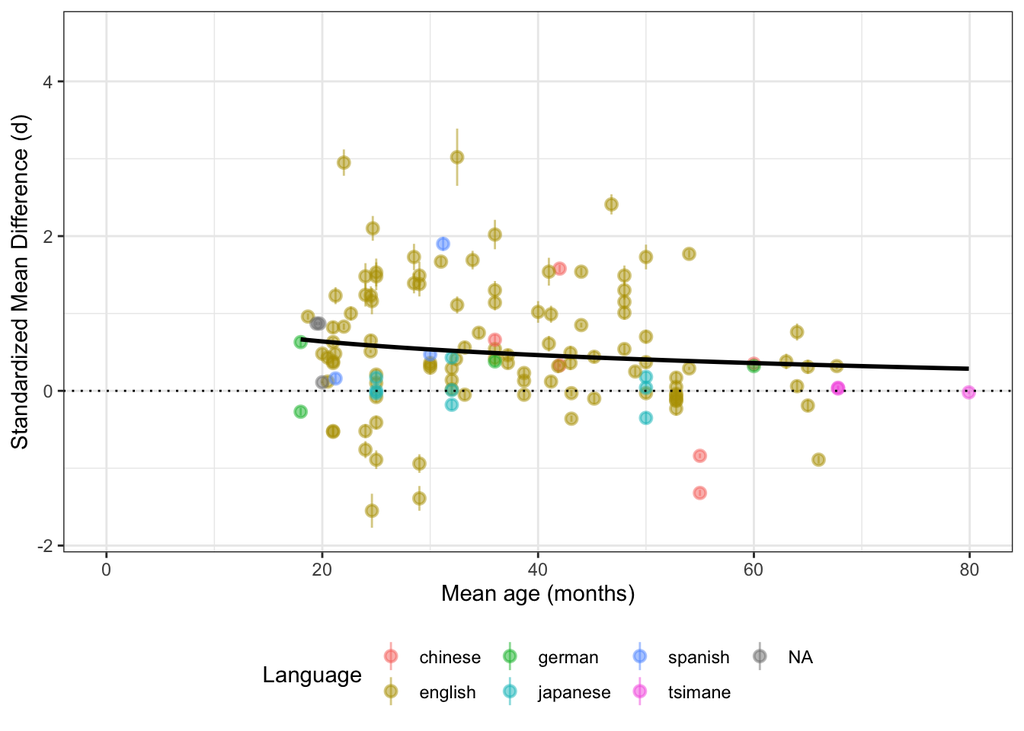

```r
ggplot(df_shape,
       aes(x = mean_age_months, y = d, color = language))+
  geom_pointrange(aes(ymin = d - d_var, ymax = d + d_var),
                  alpha = .5) +
  geom_smooth(aes(group = 1),
              col = "black",
              method = "lm", se = FALSE,
              formula = y ~ log(x)) +
  geom_hline(yintercept = 0, lty = 3) +
  ylab("Standardized Mean Difference (d)") +
  xlab("Mean age (months)") +
  scale_color_discrete(name = "Language") +
  scale_linetype_discrete(name = "Indo-European") +
  theme(legend.position = "bottom") +
  xlim(0,80)
```

### polynoial age

```r
mod_poly <- rma.mv(d ~ mean_age_months_centered36 + I(mean_age_months_centered36^2),
                   V = d_var,
                   random = ~1 | as.factor(Title) /
                     as.factor(exp_num),
                   slab = Title,
                   data = filter(df_shape, !is.na(log_mean_age_months)))

summary(mod_poly)
```

```
##
## Multivariate Meta-Analysis Model (k = 132; method: REML)
##
##    logLik   Deviance        AIC        BIC       AICc
## -303.1769   606.3538   616.3538   630.6528   616.8416
##
## Variance Components:
##
##             estim    sqrt  nlvls  fixed                               factor
## sigma^2.1  0.0984  0.3138     25     no                     as.factor(Title)
## sigma^2.2  0.0423  0.2056     33     no  as.factor(Title)/as.factor(exp_num)
##
## Test for Residual Heterogeneity:
## QE(df = 129) = 829.1803, p-val < .0001
##
## Test of Moderators (coefficients 2:3):
## QM(df = 2) = 45.6512, p-val < .0001
##
## Model Results:
##
##                                  estimate      se     zval    pval    ci.lb
## intrcpt                            0.6197  0.0892   6.9485  <.0001   0.4449
## mean_age_months_centered36        -0.0048  0.0037  -1.2926  0.1961  -0.0121
## I(mean_age_months_centered36^2)   -0.0007  0.0002  -4.1852  <.0001  -0.0011
##                                    ci.ub
## intrcpt                           0.7945  ***
## mean_age_months_centered36        0.0025
## I(mean_age_months_centered36^2)  -0.0004  ***
##
## ---
## Signif. codes:  0 '***' 0.001 '**' 0.01 '*' 0.05 '.' 0.1 ' ' 1
```

### model comparison and plotting AICc , what is the criteria ? cutoff

```r
#anova(mod_log_age, mod_poly, refit = TRUE)
#anova(mod_age, mod_poly) ## the two models are not comparable, not nested

#plot_component(mod, type = "BIC")
summary(mod_intercept)$fit.stats[5,'REML']
```

```
## [1] 663.1761
```

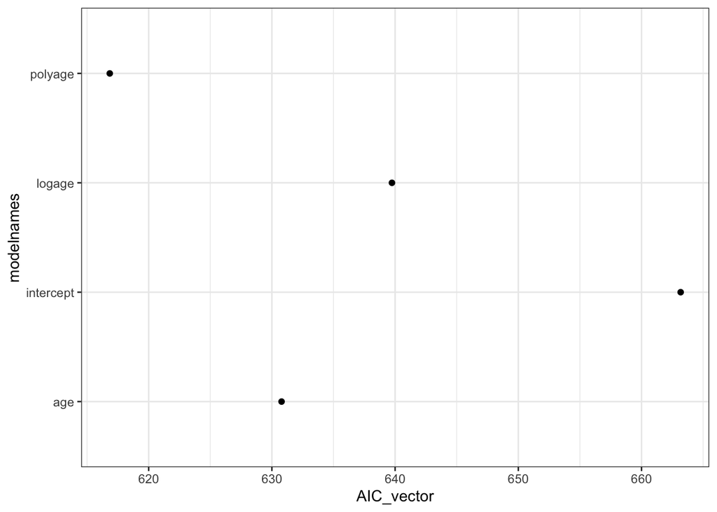

```r
AIC_vector <- c(summary(mod_intercept)$fit.stats[5,'REML'],
                summary(mod_age)$fit.stats[5,'REML'],
                summary(mod_log_age)$fit.stats[5,'REML'],
                summary(mod_poly)$fit.stats[5,'REML'])

# AIC_vector <- c(AICc(mod_intercept), AICc(mod_age), AICc(mod_log_age), AICc(mod_poly))

modelnames <- c("intercept", "age", "logage", "polyage")

data.AIC = data.frame(AIC_vector, modelnames)

ggplot(data = data.AIC, mapping = aes(x = AIC_vector, y = modelnames)) +
  geom_point()
```

## Polynomial age models

Let’s start with an interaction with `indoeuropean` with standard quadratic terms. This model is very interpretable.

```r
rma.mv(d ~ mean_age_months_centered36 * indoeuropean +
         I(mean_age_months_centered36^2) * indoeuropean,
       V = d_var,
       random = ~ 1 | ID/exp_num,
       slab = short_cite,
       data = filter(df_shape, !is.na(exp_num), !is.na(language)))
```

```
##
## Multivariate Meta-Analysis Model (k = 129; method: REML)
##
## Variance Components:
##
##             estim    sqrt  nlvls  fixed      factor
## sigma^2.1  0.1335  0.3654     23     no          ID
## sigma^2.2  0.0308  0.1754     32     no  ID/exp_num
##
## Test for Residual Heterogeneity:
## QE(df = 123) = 754.4436, p-val < .0001
##
## Test of Moderators (coefficients 2:6):
## QM(df = 5) = 91.5051, p-val < .0001
##
## Model Results:
##
##                                                    estimate      se     zval
## intrcpt                                              0.7034  0.0988   7.1163
## mean_age_months_centered36                           0.0024  0.0042   0.5591
## indoeuropeanFALSE                                   -0.4062  0.0960  -4.2318
## I(mean_age_months_centered36^2)                     -0.0010  0.0002  -4.5380
## mean_age_months_centered36:indoeuropeanFALSE        -0.0338  0.0082  -4.1176
## indoeuropeanFALSE:I(mean_age_months_centered36^2)    0.0011  0.0003   3.4408
##                                                      pval    ci.lb    ci.ub
## intrcpt                                            <.0001   0.5097   0.8972
## mean_age_months_centered36                         0.5761  -0.0059   0.0107
## indoeuropeanFALSE                                  <.0001  -0.5943  -0.2181
## I(mean_age_months_centered36^2)                    <.0001  -0.0014  -0.0005
## mean_age_months_centered36:indoeuropeanFALSE       <.0001  -0.0498  -0.0177
## indoeuropeanFALSE:I(mean_age_months_centered36^2)  0.0006   0.0005   0.0017
##
## intrcpt                                            ***
## mean_age_months_centered36
## indoeuropeanFALSE                                  ***
## I(mean_age_months_centered36^2)                    ***
## mean_age_months_centered36:indoeuropeanFALSE       ***
## indoeuropeanFALSE:I(mean_age_months_centered36^2)  ***
##
## ---
## Signif. codes:  0 '***' 0.001 '**' 0.01 '*' 0.05 '.' 0.1 ' ' 1
```

Next try breaking down by language. Here we can see Spanish is sparse and has a huge interaction term for some reason. Probably just overfit.

```r
rma.mv(d ~ mean_age_months_centered36 * language +
         I(mean_age_months_centered36^2) * language,
       V = d_var,
       random = ~ 1 | ID/exp_num,
       slab = short_cite,
       data = filter(df_shape, !is.na(exp_num), !is.na(language)))
```

```
##
## Multivariate Meta-Analysis Model (k = 129; method: REML)
##
## Variance Components:
##
##             estim    sqrt  nlvls  fixed      factor
## sigma^2.1  0.2084  0.4565     23     no          ID
## sigma^2.2  0.0310  0.1762     32     no  ID/exp_num
##
## Test for Residual Heterogeneity:
## QE(df = 112) = 672.2426, p-val < .0001
##
## Test of Moderators (coefficients 2:17):
## QM(df = 16) = 180.4172, p-val < .0001
##
## Model Results:
##
##                                                   estimate      se     zval
## intrcpt                                             0.7275  0.5561   1.3081
## mean_age_months_centered36                         -0.1196  0.1290  -0.9270
## languageenglish                                     0.0071  0.5691   0.0125
## languagegerman                                     -1.0465  0.3533  -2.9618
## languagejapanese                                   -0.1818  0.6055  -0.3002
## languagespanish                                    17.2964  3.2782   5.2762
## languagetsimane                                     1.4406  6.8350   0.2108
## I(mean_age_months_centered36^2)                     0.0017  0.0052   0.3191
## mean_age_months_centered36:languageenglish          0.1178  0.1286   0.9157
## mean_age_months_centered36:languagegerman           0.1040  0.1436   0.7244
## mean_age_months_centered36:languagejapanese         0.1180  0.1295   0.9114
## mean_age_months_centered36:languagespanish          4.4113  0.8209   5.3737
## mean_age_months_centered36:languagetsimane         -0.0114  0.2688  -0.0423
## languageenglish:I(mean_age_months_centered36^2)    -0.0025  0.0052  -0.4757
## languagegerman:I(mean_age_months_centered36^2)     -0.0011  0.0059  -0.1912
## languagejapanese:I(mean_age_months_centered36^2)   -0.0022  0.0055  -0.3957
## languagespanish:I(mean_age_months_centered36^2)     0.2050  0.0407   5.0368
##                                                     pval     ci.lb    ci.ub
## intrcpt                                           0.1908   -0.3625   1.8175
## mean_age_months_centered36                        0.3539   -0.3725   0.1333
## languageenglish                                   0.9900   -1.1083   1.1226
## languagegerman                                    0.0031   -1.7390  -0.3540
```

[output cut: 19 more lines]

```
## languagespanish                                   ***
## languagetsimane
## I(mean_age_months_centered36^2)
## mean_age_months_centered36:languageenglish
## mean_age_months_centered36:languagegerman
## mean_age_months_centered36:languagejapanese
## mean_age_months_centered36:languagespanish        ***
## mean_age_months_centered36:languagetsimane
## languageenglish:I(mean_age_months_centered36^2)
## languagegerman:I(mean_age_months_centered36^2)
## languagejapanese:I(mean_age_months_centered36^2)
## languagespanish:I(mean_age_months_centered36^2)   ***
##
## ---
## Signif. codes:  0 '***' 0.001 '**' 0.01 '*' 0.05 '.' 0.1 ' ' 1
```

With the orthogonal polynomials, it blows up completely.

```r
rma.mv(d ~ poly(mean_age_months_centered36,2) * language,
       V = d_var,
       random = ~ 1 | ID/exp_num,
       slab = short_cite,
       data = filter(df_shape, !is.na(exp_num), !is.na(language)))
```

```
##
## Multivariate Meta-Analysis Model (k = 129; method: REML)
##
## Variance Components:
##
##             estim    sqrt  nlvls  fixed      factor
## sigma^2.1  0.2084  0.4565     23     no          ID
## sigma^2.2  0.0310  0.1762     32     no  ID/exp_num
##
## Test for Residual Heterogeneity:
## QE(df = 112) = 672.2426, p-val < .0001
##
## Test of Moderators (coefficients 2:17):
## QM(df = 16) = 180.4172, p-val < .0001
##
## Model Results:
##
##                                                         estimate        se
## intrcpt                                                   0.8310    1.3147
## poly(mean_age_months_centered36, 2)1                    -15.6298   10.3513
## poly(mean_age_months_centered36, 2)2                      4.0138   12.5770
## languageenglish                                          -0.2591    1.3324
## languagegerman                                           -1.0723    0.9990
## languagejapanese                                         -0.3837    1.3428
## languagespanish                                          65.6068   12.6838
## languagetsimane                                           1.4194    6.3349
## poly(mean_age_months_centered36, 2)1:languageenglish     13.7848   10.3218
## poly(mean_age_months_centered36, 2)2:languageenglish     -5.9723   12.5548
## poly(mean_age_months_centered36, 2)1:languagegerman      14.2181   11.5411
## poly(mean_age_months_centered36, 2)2:languagegerman      -2.7003   14.1202
## poly(mean_age_months_centered36, 2)1:languagejapanese    14.4434   10.6063
## poly(mean_age_months_centered36, 2)2:languagejapanese    -5.1865   13.1061
## poly(mean_age_months_centered36, 2)1:languagespanish   1086.8686  205.0889
## poly(mean_age_months_centered36, 2)2:languagespanish    492.7409   97.8288
## poly(mean_age_months_centered36, 2)1:languagetsimane     -1.7898   42.3090
##                                                           zval    pval
## intrcpt                                                 0.6321  0.5273
## poly(mean_age_months_centered36, 2)1                   -1.5099  0.1311
## poly(mean_age_months_centered36, 2)2                    0.3191  0.7496
## languageenglish                                        -0.1945  0.8458
```

[output cut: 19 more lines]

```
## languagejapanese                                        -3.0154     2.2481
## languagespanish                                         40.7471    90.4666  ***
## languagetsimane                                        -10.9968    13.8355
## poly(mean_age_months_centered36, 2)1:languageenglish    -6.4456    34.0152
## poly(mean_age_months_centered36, 2)2:languageenglish   -30.5793    18.6347
## poly(mean_age_months_centered36, 2)1:languagegerman     -8.4020    36.8382
## poly(mean_age_months_centered36, 2)2:languagegerman    -30.3754    24.9748
## poly(mean_age_months_centered36, 2)1:languagejapanese   -6.3445    35.2313
## poly(mean_age_months_centered36, 2)2:languagejapanese  -30.8740    20.5011
## poly(mean_age_months_centered36, 2)1:languagespanish   684.9018  1488.8354  ***
## poly(mean_age_months_centered36, 2)2:languagespanish   300.9999   684.4819  ***
## poly(mean_age_months_centered36, 2)1:languagetsimane   -84.7139    81.1343
##
## ---
## Signif. codes:  0 '***' 0.001 '**' 0.01 '*' 0.05 '.' 0.1 ' ' 1
```